[Author: cyrus2281](https://github.com/cyrus2281)

# Algorithms

Data Structures + Algorithms = Programs

#### Content

- Recursion
  - Tail Recursion
- Sorting
  - Bubble Sort
  - Selection Sort
  - Insertion Sort
  - Merge Sort
  - Quick Sort
  - Tim Sort
  - Topological Sort
  - non-Comparsion Sort
- Searching
  - Linear Search
  - Binary Search
  - Breadth First Search
  - Depth First Search
  - Weighted Methods
- Dynamic Programming
  - Bellman Ford
- Backtracking
- Greedy
  - Dijkstra's Algorithm
- Problem Solving Techniques
  - Caching
  - 2 Pointer Technique
  - Sliding Window
  - Floyd's Toroise and Hare
  - Divide & Conquer
- References

# Recursion

top

Recursion: When you defined something in terms of itself.  
a function that referese to itself inside it's fucntion  
Good for tasks that have repeated subtasks, eg sorting and searching

#### Recursion Risk

Recursion can cause stack overflow

3 steps

1. Identify the base case
2. Identify the recursive case
3. Get closer and closer and return when needed. Usually you have 2 returns

```python
counter = 0
def inception():
    global counter
    print(counter, end=" ")
    if counter > 3:
        return "Done!" #base case
    counter += 1
    return inception() #recursive case
inception()
```

```
0 1 2 3 4
```

```
'Done!'
```

```python
def factorial(num):
    if (num < 1):
        return 1
    return num * factorial(num - 1)
factorial(5)
# O(n)
```

```
120
```

```python
def fibonacci(num):
    if num < 2:
        return num
    return fibonacci(num-1) + fibonacci(num-2)
fibonacci(10)
# O(2^n)
```

```
55
```

```python
def reverseString(str) :
    if len(str) < 1:
        return ""
    return reverseString(str[1:]) + str[0]
reverseString('yoyo mastery')
```

```
'yretsam oyoy'
```

**Anything that can be done recursivly can be done iteratively**  
Recursion can help the code be dry and more readable

Recursion are best for searching and sorting in trees

### Tail Recursion

top

Tail recursion is a recursion that each stack is indepent, and does not rely on the response of the calling self.

If the programming language engine supports tail recurssion, it can have a space big o of 1.

Because the engine would remove the stack after it sees that it no longer it needs it.

But tail recursions are harder to implement, and rarely supported.

```python
def tail_factorial(num,total):
    if (num == 0):
        return total
    return tail_factorial(num -1,total*num)

tail_factorial(4,1)
```

```
24
```

# Sorting

top

2 Types:  
Comparison sort  
Non-Comparsion Sort

[figure not shown]

## Comparison sort

### Bubble Sort

top

Each pair compare to each other, the bigger one will be passed and it continue for the rest

Time Complexity Big O of n^2  
Space Complexity Big O of 1  
**Usage:** Rarely used, more educational aspects

```python
def bubbleSort(lst):
    length = len(lst) - 1
    for a in range(length):
        for b in range(length):
            if lst[b] > lst[b+1]:
                lst[b], lst[b+1] = lst[b+1], lst[b]
    return lst
bubbleSort([99,44,6,2,1,5,63,87,283,4,0])
```

```
[0, 1, 2, 4, 5, 6, 44, 63, 87, 99, 283]
```

### Selection Sort

top

Goes through the list and mark the lowest value and bring it to beginning, and repeat

Time Complexity Big O of n^2  
Space Complexity Big O of 1  
**Usage:** Mostly used for teaching purposes

```python
def selectionSort(lst):
    length = len(lst)
    for a in range(length):
        index = a
        lowest = lst[a]
        for b in range(a+1,length):
            if lowest > lst[b]:
                lowest = lst[b]
                index = b
        lst[a] , lst[index] = lst[index] , lst[a]
    return lst
selectionSort([99,44,6,2,1,5,63,87,283,4,0])
```

```
[0, 1, 2, 4, 5, 6, 44, 63, 87, 99, 283]
```

### Insertion Sort

top

Time Complexity Big O of n^2  
Space Complexity Big O of 1  
best algorithm for nearly sorted lists  
**Usage:** Small list

```python
def insertionSort(lst):
    length = len(lst)
    for b in range(1,length):
        if lst[b] <= lst[0]:
            temp = lst[b]
            del lst[b]
            lst = [temp]+lst[:]
        elif lst[b] >= lst[b-1]:
            pass
        else:
            for i in range(b):
                if lst[b] < lst[i]:
                    temp = lst[b]
                    del lst[b]
                    lst = lst[:i]+[temp]+lst[i:]
    return lst
insertionSort([99,44,6,2,1,5,63,87,283,4,0])
```

```
[0, 1, 2, 4, 5, 6, 44, 63, 87, 99, 283]
```

### Merge Sort

top

```python
def merge(left,right):
    result = []
    leftIndex = 0
    rightIndex = 0
    while leftIndex < len(left) and rightIndex < len(right):
        if left[leftIndex] < right[rightIndex]:
            result.append(left[leftIndex])
            leftIndex +=1
        else:
            result.append(right[rightIndex])
            rightIndex+=1
    return result+left[leftIndex:]+right[rightIndex:];

def mergeSort(lst):
    if len(lst) == 1:
        return lst
    mid = len(lst)//2
    return merge(mergeSort(lst[:mid]),mergeSort(lst[mid:]))

mergeSort([99,44,6,2,1,5,63,87,283,4,0])
```

```
[0, 1, 2, 4, 5, 6, 44, 63, 87, 99, 283]
```

### Quick Sort

top

Time Complexity Big O of n log n (worst case O(n^2) if pivot is the smallest or the largest)  
Space Complexity Big O of log n  
uses divide and conquer method  
**Usage:** Most popular algorithm, but the worst case is very expensive

```python
#My version
def quickSort(lst):
    if len(lst) == 2:
        if lst[0] > lst[1]:
            return [lst[1],lst[0]]
        else:
            return lst
    elif len(lst) <= 1:
        return lst
    #divide
    pivot = lst[len(lst)-1]
    left = []
    right = []
    for i in range(len(lst)-1):#if pivot is not the last item,
        #here should change to len(lst),
        #and the iteration which the count is same as pivot should be skipped
        if lst[i] < pivot:
            left.append(lst[i])
        else:
            right.append(lst[i])
    return quickSort(left) + [pivot] + quickSort(right)

quickSort([99,44,6,2,1,5,63,87,283,4,0])
```

```
[0, 1, 2, 4, 5, 6, 44, 63, 87, 99, 283]
```

```python
# Given algorithm
def swap(array, firstIndex, secondIndex):
    array[firstIndex], array[secondIndex] = array[secondIndex], array[firstIndex]

def partition(array, pivot, left, right):
    pivotValue = array[pivot]
    partitionIndex = left
    for i in range(left,right):
        if array[i] < pivotValue:
            swap(array, i, partitionIndex)
            partitionIndex+=1
    swap(array, right, partitionIndex)
    return partitionIndex

def quickSort(array, left, right):
    if left < right :
        pivot = right
        partitionIndex = partition(array, pivot, left, right)
        #sort left and right
        quickSort(array, left, partitionIndex - 1)
        quickSort(array, partitionIndex + 1, right)
    return array


#Select first and last index as 2nd and 3rd parameters
numbers = [99, 44, 6, 2, 1, 5, 63, 87, 283, 4, 0]
quickSort(numbers, 0, len(numbers)- 1)
print(numbers)
```

```
[0, 1, 2, 4, 5, 6, 44, 63, 87, 99, 283]
```

### Tim Sort

top

Timsort is a hybrid stable sorting algorithm, derived from merge sort and insertion sort, designed to perform well on many kinds of real-world data. It was implemented by Tim Peters in 2002 for use in the Python programming language. The algorithm finds subsequences of the data that are already ordered (runs) and uses them to sort the remainder more efficiently. This is done by merging runs until certain criteria are fulfilled

Time Complexity Big O of n log n  
Space Complexity Big O of n

uses a hybrid of merge and isertion sort  
**Usage:** Python's default sort algorithm

```python
MIN_MERGE = 32

def calcMinRun(n):
    r = 0
    while n >= MIN_MERGE:
        r |= n & 1
        n >>= 1
    return n + r

def insertionSort(arr, left, right):
    for i in range(left + 1, right + 1):
        j = i
        while j > left and arr[j] < arr[j - 1]:
            arr[j], arr[j - 1] = arr[j - 1], arr[j]
            j -= 1

def merge(arr, l, m, r):
    len1, len2 = m - l + 1, r - m
    left, right = [], []
    for i in range(0, len1):
        left.append(arr[l + i])
    for i in range(0, len2):
        right.append(arr[m + 1 + i])
    i, j, k = 0, 0, l
    while i < len1 and j < len2:
        if left[i] <= right[j]:
            arr[k] = left[i]
            i += 1
        else:
            arr[k] = right[j]
            j += 1
        k += 1
    while i < len1:
        arr[k] = left[i]
        k += 1
        i += 1
    while j < len2:
        arr[k] = right[j]
        k += 1
        j += 1

def timSort(arr):
    n = len(arr)
    minRun = calcMinRun(n)
    for start in range(0, n, minRun):
        end = min(start + minRun - 1, n - 1)
        insertionSort(arr, start, end)
    size = minRun
    while size < n:
        for left in range(0, n, 2 * size):
            mid = min(n - 1, left + size - 1)
            right = min((left + 2 * size - 1), (n - 1))
            if mid < right:
                merge(arr, left, mid, right)
        size = 2 * size
```

### Topological Sort

top

This sort algorithm is used for Directed Acylic Graphs (DAG)

It sorts nodes with least Indegrees to the most

Indegree: indegrees are the incoming vertexes to each node

How this works is that it first create an indegree list for all nodes. Then we start by removing nodes which have an indegree of 0. When removing a node we should also reduce the indegree of all other nodes depending on that. We keep going till all nodes have reach indegree of zero and removed.

Warning: if the graph is not acylic (there is a loop in it) we won't be able to remove all nodes. This can also be used to see if there is a loop in a graph

[figure not shown]

```python
edges = [[1,0],[2,1],[2,5],[0,3],[4,3],[3,5],[4,5]]
def topologicalSort(numCourses, prerequisites):
    lst = [[] for i in range(numCourses)]
    indegree = [0 for i in range(numCourses)]
    for pair in prerequisites:
        lst[pair[1]].append(pair[0])
        indegree[pair[0]]+= 1

    print("Adjacent List: ", lst)
    print("Indegrees:     ", indegree)
    sortedList = []

    stack = [a for a,b in enumerate(indegree) if b == 0]
    while stack:
        v, stack = stack[0],stack[1:]
        sortedList.append(v)
        for i in lst[v]:
            if (indegree[i]-1 == 0):
                stack.append(i)
            indegree[i] -= 1
    return sortedList
topologicalSort(6, edges)
```

```
Adjacent List:  [[1], [2], [], [0, 4], [], [2, 3, 4]]
Indegrees:      [1, 1, 2, 1, 2, 0]
```

```
[5, 3, 0, 4, 1, 2]
```

### Non-comparsion Sort

top

uses the way data is stored in memory (binary)  
It works only with integers in a small range  
Examples are:

1. Radix Sort : time complexity if O(nk), space O(n+k)
2. Counting Sort: time complexity if O(n+k), space O(k)

**Choosing a the most proper sorting algorithm for the following cases:**

1 - Sort 10 schools around your house by distance: **insertion sort**

2 - eBay sorts listings by the current Bid amount: **radix or counting sort**

3 - Sport scores on ESPN: **quick sort**

4 - Massive database (can't fit all into memory) needs to sort through past year's user data: **merge sort**

5 - Almost sorted Udemy review data needs to update and add 2 new reviews: **insertion sort**

7 - Large user name database needs to be sorted. Data is very random.: **merge or quick sort**

8 - You want to teach sorting for the first time: **Bubble, selection sort**

# Searching

top

### Linear Search

top

Sequentially goes through items can compare each item with the searching value

Time Complexity of big O of n

```python
def linearSearch(lst,value):
    for i in lst:
        if i == value:
            return True
    return False
linearSearch([99,44,6,2,1,5,63,87,283,4,0], 5)
```

```
True
```

### Binary Search

top

requires a sorted list

Time Complexity of big O of log n

```python
def binarySearch(arr, x):
    low = 0
    high = len(arr) - 1
    mid = 0
    while low <= high:
        mid = (high + low) // 2
        if arr[mid] < x:
            low = mid + 1 #ignore left half
        elif arr[mid] > x:
            high = mid - 1 # ignore right half
        else:
            return mid
    return -1

binarySearch([0, 1, 2, 4, 5, 6, 44, 63, 87, 99, 283], 5)
```

```
4
```

```python
# binary tree code for following topic
class Node:
    def __init__(self,value):
        self.left = None
        self.right = None
        self.value = value
class BinaryTree:
    def __init__(self):
        self.root = None

    def insert(self, value):
        leaf = Node(value)
        if not self.root:
            self.root = leaf
            return
        node = self.root
        while node:
            temp = node
            if leaf.value < node.value:
                node = node.left
                if not node:
                    temp.left = leaf
            else:
                node = node.right
                if not node:
                    temp.right = leaf

    #divid and conquer
    def lookup(self,value):
        if self.root.value == value:
            return True
        node = self.root
        while node:
            if value < node.value:
                node = node.left
            elif value == node.value:
                return True
            else:
                node = node.right
        return False

    def bfs(self):
        currentNode = self.root
        lst = []
        queue = []
        queue.append(currentNode)

        while len(queue) > 0:
            currentNode = queue[0] #shift
            queue = queue[1:]
            lst.append(currentNode.value)
            if currentNode.left:
                queue.append (currentNode.left)
            if currentNode.right:
                queue.append (currentNode.right)
        return lst

    def dfs(self,node,lst):
        if node == None:
            return
        lst.append(node.value) #lst here for pre order
        self.dfs(node.left, lst)
        #lst here for in order
        self.dfs(node.right, lst)
        #lst here for post order
        return lst

    def dfsInorderIterative(self):
        lst = []
        stack = []
        node = self.root
        while stack or node is not None:
            if node is not None:
                stack.append(node)
                node = node.left
            else:
                node = stack.pop()
                lst.append(node.value)
                node = node.right
        return lst


"""
     9
   /   \
  4     20
 / \   /  \
1   6 15  170
"""
tree = BinaryTree()
tree.insert(9)
tree.insert(4)
tree.insert(6)
tree.insert(20)
tree.insert(170)
tree.insert(15)
tree.insert(1)

print(tree.bfs())
print(tree.dfs(tree.root,[]))
print(tree.dfsInorderIterative())
```

```
[9, 4, 20, 1, 6, 15, 170]
[9, 4, 1, 6, 20, 15, 170]
[1, 4, 6, 9, 15, 20, 170]
```

### Breadth First Search

top

Time Complexity of big O of n

for graph traversal

goes down through the tree level by level

for previous tree the order would be: 9 4 20 1 6 15 170

**Cons:**  
Shortest path  
Closer nodest  
**Prons:**  
More Memory

```python
def breadthFirstSearch(queue, value):
    if len(queue) < 1:
        return False
    currentNode = queue.pop()
    if currentNode.value == value:
        return True
    if currentNode.left:
        queue.append (currentNode.left)
    if currentNode.right:
        queue.append (currentNode.right)
    return breadthFirstSearch(queue, value)

breadthFirstSearch([tree.root],15)
```

```
True
```

## Depth First Search in 2-D array:

order of search: UP -> RIGHT -> DOWN -> LEFT

[figure not shown]

```python
array = [
    [1, 2, 3, 4, 5 ],
    [6, 7, 8, 9, 10],
    [11,12,13,14,15],
    [16,17,18,19,20],
]

def dfs_2D_array_search(matrix):
    # DFS Directions
    directions = [
    (-1,0), #up
    (0, 1), #right
    (1, 0), #down
    (0,-1)  #left
    ]
    #this creates a 2D replica of the matrix with only false boolean values
    """
    [[F, F, F, F, F],
     [F, F, F, F, F],
     [F, F, F, F, F],
     [F, F, F, F, F]]
    """
    seen = [ [False for j in range(len(matrix[0]))] for i in range(len(matrix))]
    values = []
    def dfs(matrix,row,col,seen,val):
        if row < 0 or col < 0 or row >= len(matrix) or col >= len(matrix[0]) or seen[row][col]:
            return
        seen[row][col] = True
        val.append(matrix[row][col])
        for i,j in directions:
            dfs(matrix,row+i,col+j,seen,values)
    dfs(matrix,0,0,seen,values)
    return values

dfs_2D_array_search(array)
```

```
[1, 2, 3, 4, 5, 10, 15, 20, 19, 14, 9, 8, 13, 18, 17, 12, 7, 6, 11, 16]
```

## Breadth First Search in Graphs:

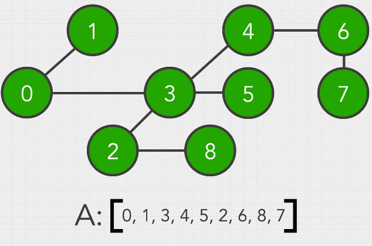

```python
adjList = [[1,3], [0],[3,8],[0,4,5,2],[3,6],[3],[4,7],[6],[2]]

def graph_bfs(graph):
    queue = [0]
    visited = []
    while queue:
        vertex, queue = queue[0], queue[1:]
        visited.append(vertex)
        for connection in graph[vertex]:
            if connection not in visited:
                queue.append(connection)
    return visited

graph_bfs(adjList)
```

```
[0, 1, 3, 4, 5, 2, 6, 8, 7]
```

### Depth First Search

top

Time Complexity of big O of n

for tree traversal

goes down through one branch till there is no more childern, then goes back up and goes to the other childern

for previous tree the order would be: 9 4 1 6 20 15 170

**Cons:**  
Less Memory  
Does path exist?  
**Prons:**  
can get slow

101  
| \  
33 105  
**3 Types:**  
inorder - 33 101 105 (after left)  
preorder 101 33 105 (at beginning)  
postorder 33 105 101 (after right)

```python
def depthFirstSearch(node, value):
    if node == None:
        return False

    if node.value == value:
        return True
    if depthFirstSearch(node.left, value):
        return True
    if depthFirstSearch(node.right, value):
        return True
    return False

depthFirstSearch(tree.root,15)
```

```
True
```

#### Breadth First Search in 2-D array:

order of search: UP -> RIGHT -> DOWN -> LEFT

[figure not shown]

```python
array = [
    [1, 2, 3, 4, 5 ],
    [6, 7, 8, 9, 10],
    [11,12,13,14,15],
    [16,17,18,19,20],
]

def bfs_2D_array_search(matrix):
    directions = [
    (-1,0), #up
    (0, 1), #right
    (1, 0), #down
    (0,-1)  #left
    ]
    seen = [ [False for j in range(len(matrix[0]))] for i in range(len(matrix))]
    row,col =len(matrix)//2, len(matrix[0])//2 # middle of the matrix, or start from (0,0)
    values = [matrix[row][col]]
    queue = [(row,col)]
    seen[row][col] = True
    while queue:
        point, queue = queue[0], queue[1:]
        row,col = point
        for i,j in directions:
            if row+i < 0 or col+j < 0 or row+i >= len(matrix) or col+j >= len(matrix[0]) or seen[row+i][col+j]:
                continue
            else:
                seen[row+i][col+j] = True
                values.append(matrix[row+i][col+j])
                queue.append((row+i,col+j))
    return values

bfs_2D_array_search(array)
```

```
[13, 8, 14, 18, 12, 3, 9, 7, 15, 19, 17, 11, 4, 2, 10, 6, 20, 16, 5, 1]
```